# 4. CASE STUDY: BABY NAMES

### 4.1 The Babynames dataset

Load `tidyverse`:

```r
library(tidyverse)
```

Load the `Babynames` dataset, which represents the names of babies born in the US each year:

```r
babynames <- readRDS("babynames.rds")
```

Examine the dataset:

```r
glimpse(babynames)
```

```
## Rows: 332,595
## Columns: 3
## $ year   <dbl> 1880, 1880, 1880, 1880, 1880, 1880, 1880, 1880, 1880, 1880, ...
## $ name   <chr> "Aaron", "Ab", "Abbie", "Abbott", "Abby", "Abe", "Abel", "Ab...
## $ number <int> 102, 5, 71, 5, 6, 50, 9, 12, 27, 81, 21, 652, 24, 23, 104, 1...
```

Find the frequency of a name in each year, for example, “Amy”:

```r
babynames_filtered <- babynames %>%
  filter(name == "Amy")
```

Use `ggplot2` to generate a plot for the filtered name:

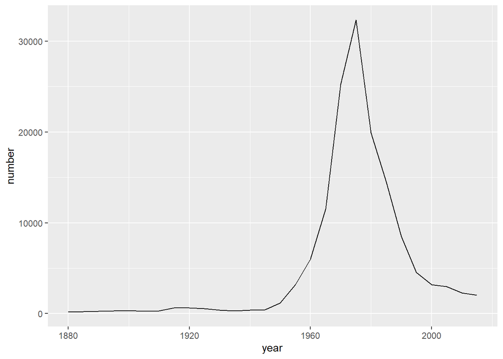

```r
ggplot(babynames_filtered,
       aes(year, number)) +
  geom_line()
```

The plot shows many babies born in the 70s and 80s were named “Amy”, but relatively few today.

Filter for multiple names:

```r
babynames_multiple <- babynames %>%
  filter(name %in% c("Amy", "Christopher"))
```

Visualize these names as a line plot over time:

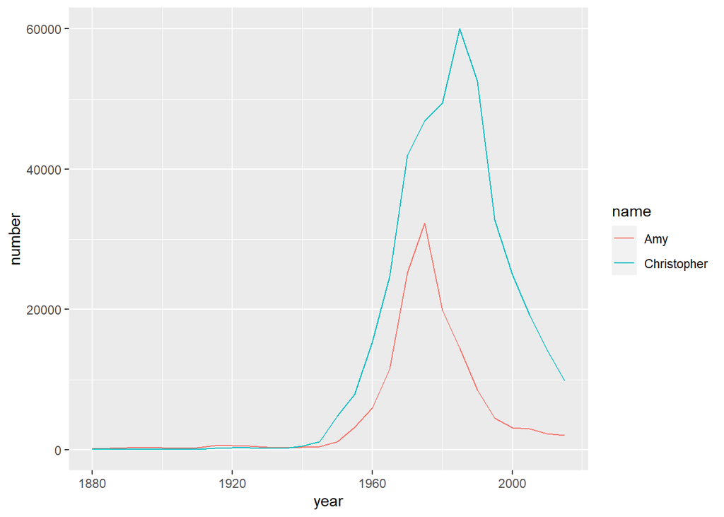

```r
ggplot(babynames_multiple,
       aes(year, number,
           color = name)) +
  geom_line()
```

Filter and arrange for one year:

```r
babynames %>%
  filter(year == 1990) %>%
  arrange(desc(number))
```

```
## # A tibble: 21,223 x 3
##     year name        number
##    <dbl> <chr>        <int>
##  1  1990 Michael      65560
##  2  1990 Christopher  52520
##  3  1990 Jessica      46615
##  4  1990 Ashley       45797
##  5  1990 Matthew      44925
##  6  1990 Joshua       43382
##  7  1990 Brittany     36650
##  8  1990 Amanda       34504
##  9  1990 Daniel       33963
## 10  1990 David        33862
## # ... with 21,213 more rows
```

Find the most common names in one year:

```r
babynames %>%
  group_by(year) %>%
  top_n(1, number)
```

```
## # A tibble: 28 x 3
## # Groups:   year [28]
##     year name  number
##    <dbl> <chr>  <int>
##  1  1880 John    9701
##  2  1885 Mary    9166
##  3  1890 Mary   12113
##  4  1895 Mary   13493
##  5  1900 Mary   16781
##  6  1905 Mary   16135
##  7  1910 Mary   22947
##  8  1915 Mary   58346
##  9  1920 Mary   71175
## 10  1925 Mary   70857
## # ... with 18 more rows
```

### 4.3 Grouped mutate

Filter for the names Steven, Thomas, and Matthew:

```r
selected_names <- babynames %>%
  filter(name %in% c("Steven", "Thomas", "Matthew"))
```

Visualize the names over time:

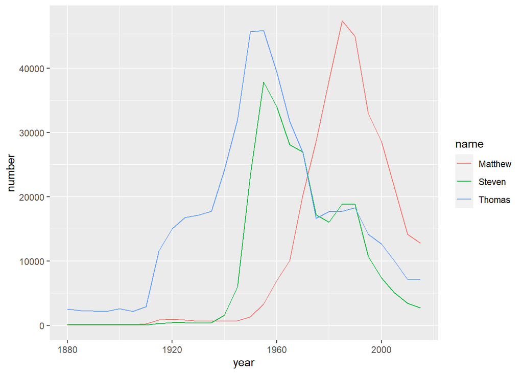

```r
ggplot(selected_names,
       aes(year, number,
           color = name)) +
  geom_line()
```

A different total of number of babies are born in each year, and what we are interested in is what percentage of people born in that year have that name. To calculate that, you have to use grouped mutate.

```r
babynames_fraction <- babynames %>%
  group_by(year) %>%
  mutate(year_total = sum(number)) %>%
  # ungroup() when you're done with the groups
  ungroup() %>%
  # calculate the fraction of people born in each year that have each name.
  mutate(fraction = number/year_total)
```

Filter the three names again:

```r
selected_names <- babynames_fraction %>%
  filter(name %in% c("Steven", "Thomas", "Matthew"))
```

Graph again the three names but use `fraction` instead of `number`:

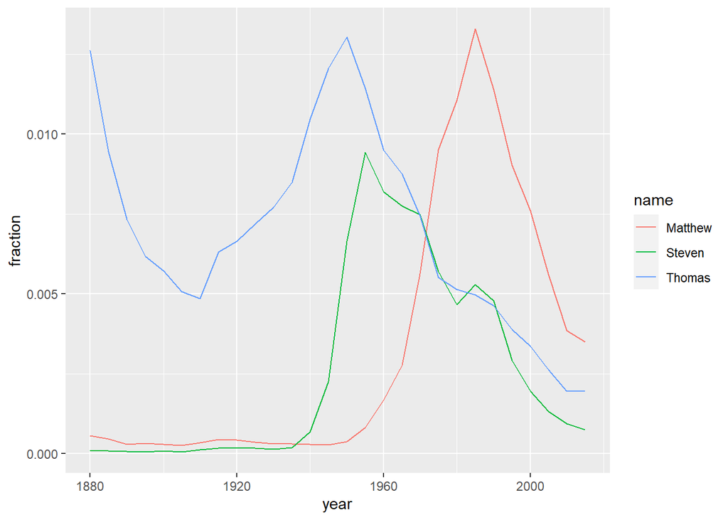

```r
ggplot(selected_names,
       aes(year, fraction,
           color = name)) +
  geom_line()
```

The graph looks different, because the dataset includes relatively few babies from 1800s and early 1900s.

Adding the total and maximum for each name:

```r
babynames %>%
  group_by(name) %>%
  mutate(name_total = sum(number),
         name_max = max(number)) %>%
  ungroup() %>%
  mutate(fraction_max = number/name_max)
```

```
## # A tibble: 332,595 x 6
##     year name    number name_total name_max fraction_max
##    <dbl> <chr>    <int>      <int>    <int>        <dbl>
##  1  1880 Aaron      102     114739    14635     0.00697
##  2  1880 Ab           5         77       31     0.161
##  3  1880 Abbie       71       4330      445     0.160
##  4  1880 Abbott       5        217       51     0.0980
##  5  1880 Abby         6      11272     1753     0.00342
##  6  1880 Abe         50       1832      271     0.185
##  7  1880 Abel         9      10565     3245     0.00277
##  8  1880 Abigail     12      72600    15762     0.000761
##  9  1880 Abner       27       1552      199     0.136
## 10  1880 Abraham     81      17882     2449     0.0331
## # ... with 332,585 more rows
```

Pick a few names and calculate each of them as a fraction of their peak. This is a type of *normalizing* a name, where you’re focused on the relative change within each name rather than the overall popularity of the name.

```r
names_normalized <- babynames %>%
  group_by(name) %>%
  mutate(name_total = sum(number),
         name_max = max(number)) %>%
  ungroup() %>%
  mutate(fraction_max = number / name_max)
```

Filter for the names Steven, Thomas, and Matthew:

```r
names_filtered <- names_normalized %>%
  filter(name %in% c("Steven", "Thomas", "Matthew"))
```

Visualize these names over time:

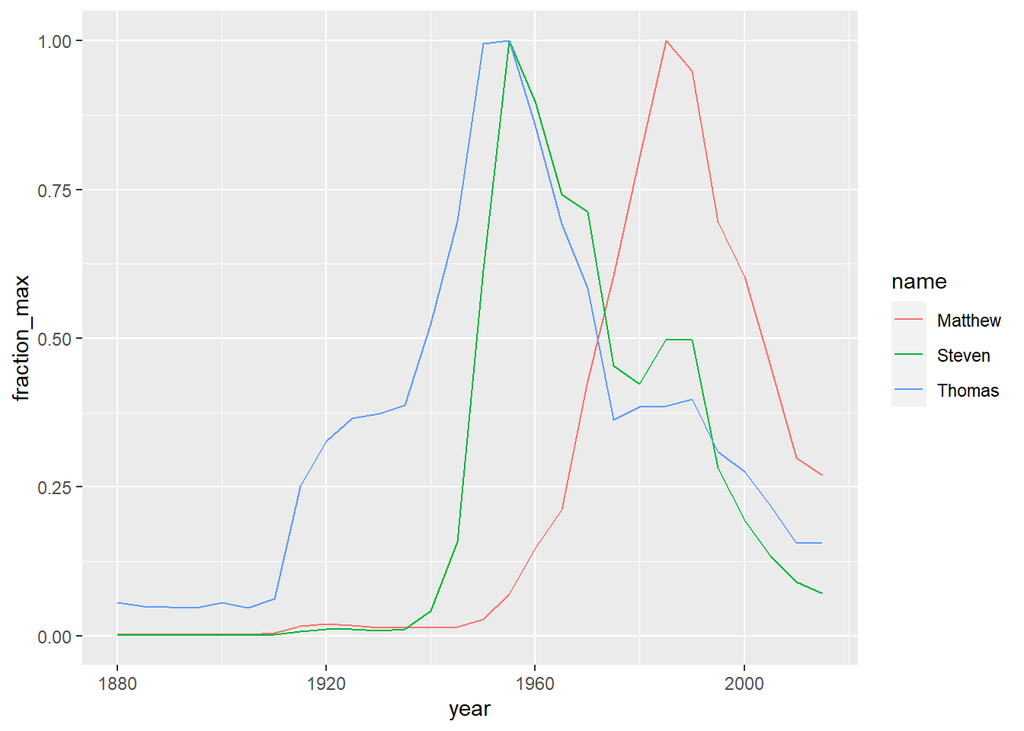

```r
ggplot(names_filtered,
      aes(year, fraction_max,
          color = name)) +
  geom_line()
```

### 4.3 lag() function

You have discovered a few names that have gone through major changes over time. But what if you want to look at the biggest changes within each name? To do this, you have to find differences between each pair of consecutive years with the `lag()` function of the **dplyr**.

`lag()` takes a vector and returns another of the same length. For example:

```r
v <- c(1, 3, 6, 14)
lag(v) # move each item to the right by one.
```

```
## [1] NA  1  3  6
```

By lining up each item in the vector with the item directly before it, we can compare consecutive steps and calculate the changes.

Find the changes in the popularity of the name “Matthew” in consecutive years:

```r
babynames_fraction %>%
  filter(name == "Matthew") %>%
  arrange(year) %>%
  mutate(difference = fraction - lag(fraction)) %>%
  arrange(desc(difference))
```

```
## # A tibble: 28 x 6
##     year name    number year_total fraction difference
##    <dbl> <chr>    <int>      <int>    <dbl>      <dbl>
##  1  1975 Matthew  28665    3014943 0.00951   0.00389
##  2  1970 Matthew  20265    3604252 0.00562   0.00286
##  3  1985 Matthew  47367    3563364 0.0133    0.00223
##  4  1980 Matthew  38054    3439117 0.0111    0.00156
##  5  1965 Matthew  10015    3624610 0.00276   0.00109
##  6  1960 Matthew   6942    4152075 0.00167   0.000853
##  7  1955 Matthew   3287    4012691 0.000819  0.000447
##  8  1915 Matthew    798    1830351 0.000436  0.000102
##  9  1950 Matthew   1303    3502592 0.000372  0.0000967
## 10  1910 Matthew    197     590607 0.000334  0.0000811
## # ... with 18 more rows
```

The first observation is missing a difference, because there is no previous year. After that we can see whether the popularity of “Matthew” goes up or down. By arranging the table in descending order in the difference, we could see the biggest jump in popularity is in 1975 and 1970.

```r
babynames_fraction %>%
  arrange(name, year) %>%
  mutate(difference = fraction - lag(fraction)) %>%
  group_by(name) %>%
  arrange(desc(difference))
```

```
## # A tibble: 332,595 x 6
## # Groups:   name [48,040]
##     year name    number year_total fraction difference
##    <dbl> <chr>    <int>      <int>    <dbl>      <dbl>
##  1  1880 John      9701     201478   0.0481     0.0481
##  2  1880 William   9562     201478   0.0475     0.0475
##  3  1880 Mary      7092     201478   0.0352     0.0352
##  4  1880 James     5949     201478   0.0295     0.0295
##  5  1880 Charles   5359     201478   0.0266     0.0266
##  6  1880 George    5152     201478   0.0256     0.0256
##  7  1880 Frank     3255     201478   0.0162     0.0162
##  8  1935 Shirley  42790    2088487   0.0205     0.0137
##  9  1880 Joseph    2642     201478   0.0131     0.0131
## 10  1880 Anna      2616     201478   0.0130     0.0129
## # ... with 332,585 more rows
```

Using ratios to describe the frequency of a name:

```r
babynames_ratios <- babynames_fraction %>%
  arrange(name, year) %>%
  group_by(name) %>%
  mutate(ratio = fraction/lag(fraction))
```

Look further into the names that experienced the biggest jumps in popularity in consecutive years:

```r
babynames_ratios %>%
  top_n(1, ratio) %>%
  arrange(desc(ratio)) %>%
  filter(fraction >= 0.001)
```

```
## # A tibble: 286 x 6
## # Groups:   name [286]
##     year name    number year_total fraction ratio
##    <dbl> <chr>    <int>      <int>    <dbl> <dbl>
##  1  1960 Tammy    14365    4152075  0.00346  70.1
##  2  2005 Nevaeh    4610    3828460  0.00120  45.8
##  3  1940 Brenda    5460    2301630  0.00237  37.5
##  4  1885 Grover     774     240822  0.00321  36.0
##  5  1945 Cheryl    8170    2652029  0.00308  24.9
##  6  1955 Lori      4980    4012691  0.00124  23.2
##  7  2010 Khloe     5411    3672066  0.00147  23.2
##  8  1950 Debra     6189    3502592  0.00177  22.6
##  9  2010 Bentley   4001    3672066  0.00109  22.4
## 10  1935 Marlene   4840    2088487  0.00232  16.8
## # ... with 276 more rows
```

The jump in 1885 of “Grover” can be explained: Grover Cleveland was a president elected in 1884.